# Reveals, at the veil’s pace

### Scratch

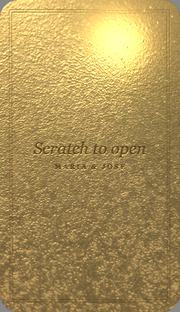

[figure not shown]

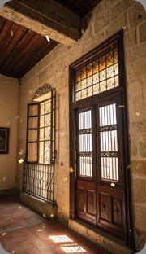

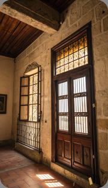

The gold comes off only where you rub and curls of foil fall. At 60% the rest crumbles away, slowly.

**You do**

Scratch with your finger. It opens at 60%.

**Status**

As before, at the veil’s pace.

7

### Smoke

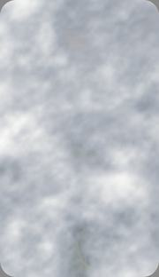

Dry-ice fog: slow, heavy, rolling. A tap sends a ring outward from the exact spot, the way a drop does in water, and a second, fainter ring follows. The fog thins behind them.

**You do**

Tap anywhere. The ring starts under your finger.

**Status**

Rebuilt: slower, low and rolling, opens in rings.

8

### Cathedral doors

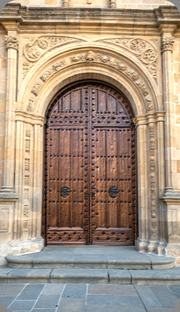

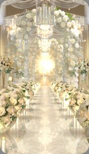

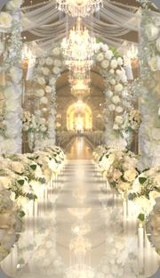

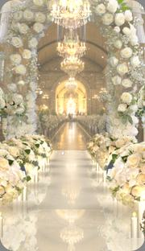

Shut, with a thin seam of light. The leaves swing inward and light bursts through the gap. Then one unbroken glide: through the doorway and down a wide hall, over a polished marble floor that mirrors the chandeliers and the flowers, between round arrangements that line the aisle and tall ones on gold stands, under chiffon and flower arches, motes of light drifting past, into the white, and the cover is there. Near things stream by, far things grow slowly: a camera moving through a real space.

**You do**

Tap the doors.

**Status**

Finish pass, 23 Nov: a floor that mirrors the hall, flowers at true scale with soft edges, a wider hall.

9

### Petals

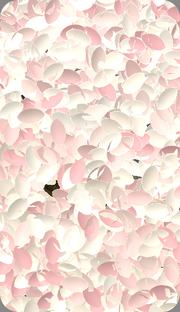

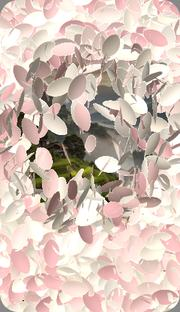

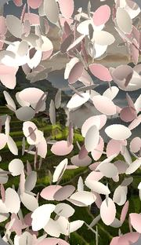

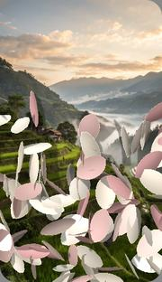

The cover lies under sampaguita and rose petals. A tap is a breath: they lift in a ring from the finger, tumble, and drift down slowly.

**You do**

Tap anywhere. They lift from your finger.

**Status**

New. Picked by you, 23 Nov. Now falling slower.

10

### Fireworks

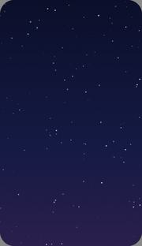

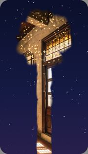

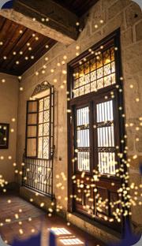

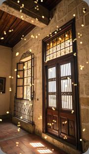

The cover waits under a night sky. One rocket climbs from your finger and bursts. Wherever the gold sparks fall, the night melts away. Two more bursts follow, and the last of the dark goes in glitter.

**You do**

Tap anywhere. The rocket goes up from your finger.

**Status**

New, from your own idea of sparkles. Picked by you, 23 Nov.

## More designs to choose from

### Envelope · classic

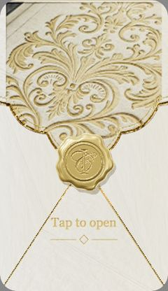

Scalloped

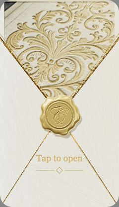

Deep V

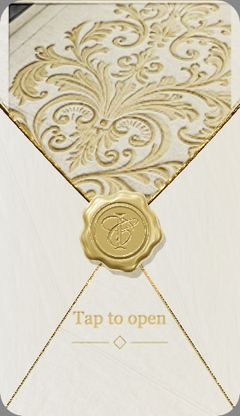

Pointed Euro

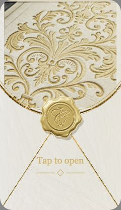

Rounded

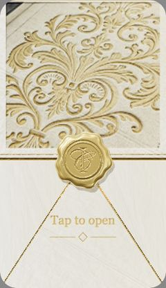

Square

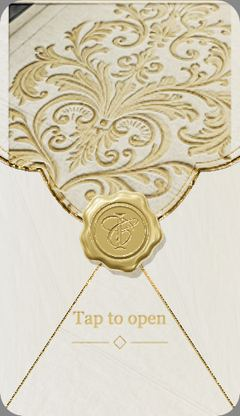

Double scallop

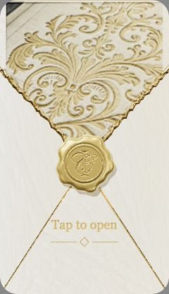

Deckle edge

**Flap shape**Scalloped

- Scalloped
- Deep V
- Pointed Euro
- Rounded
- Square
- Double scallop
- Deckle edge

**Flap design**Damask

**Paper colour**Ivory

**Seal**Gold

### Envelope · gatefold

[figure not shown]

Art deco

[figure not shown]

Botanical line

[figure not shown]

Lace

[figure not shown]

Geometric

[figure not shown]

Monogram field

[figure not shown]

Pressed florals

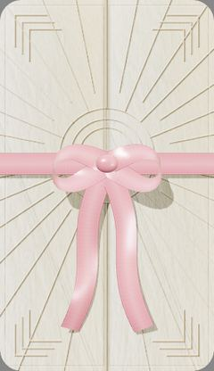

Art deco, with ribbon

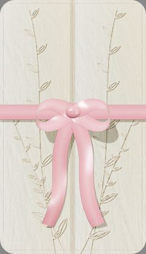

Botanical line, with ribbon

**Closed with**Wax seal

**Panel design**Sculpted lilies

- Sculpted lilies
- Damask
- Plain with border
- Art deco
- Botanical line
- Lace
- Geometric
- Monogram field
- Pressed florals

**Paper colour**Ivory

**Ribbon**Blush

**Seal**Gold

### Fabric

[figure not shown]

Chiffon

[figure not shown]

Velvet

[figure not shown]

Linen

[figure not shown]

Organza

[figure not shown]

Tulle

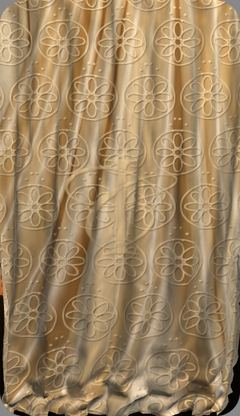

Lace

**Fabric**Plain satin

- Plain satin
- Damask jacquard
- Raw mulberry silk
- Chiffon
- Velvet
- Linen
- Organza
- Tulle
- Lace

**Colour**Champagne

### Envelope · gatefold, ribbon in the breeze

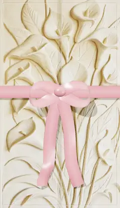

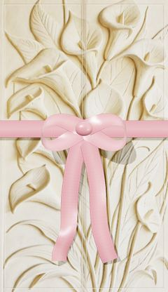

Ribbon tails

## Held, and redrawn: the gift box

You said it still needed work, so it is not one of the nine. This is the redraw. Frames: closed, then about 4, 7 and 9.5 seconds after the tap, at the 12-second speed.

+

### Gift box · redrawn

[figure not shown]

[figure not shown]

[figure not shown]

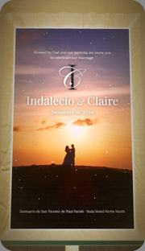

A wrapped box in one pool of warm light on a dark table. Deep green paper with your monogram in gold foil, the end folded the way a present is wrapped. A satin ribbon crosses it and is tied in a full bow. Around it lies an arrangement you choose: flowers, petals, pearls, diamonds, confetti, balloons or gold stars. A soft breeze moves the flowers, the petals and the loose ribbon; diamonds and gold stars sparkle. The box throws its shadow on the ground. One tap: the bow comes undone, and the four lengths of ribbon open outward and settle on the ground like a flower opening. Nothing is dragged across the box. Then the lid opens slowly, light comes up from inside over gold tissue, and the view comes over the box and down until the cover fills the screen.

**You do**

Tap the bow.

**Status**

[figure not shown]

[figure not shown]

Breeze

[figure not shown]

[figure not shown]

Diamonds

[figure not shown]

[figure not shown]

Gold stars

[figure not shown]

[figure not shown]

Opening

[figure not shown]

Cotton clouds

[figure not shown]

Egyptian cotton

[figure not shown]

Ivory clouds

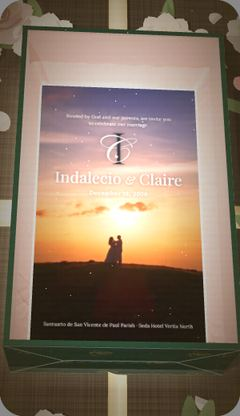

Blush silk

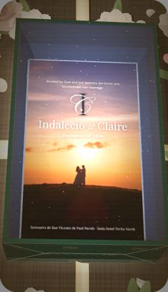

Navy velvet

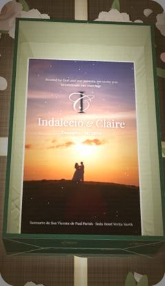

Sage linen

[figure not shown]

Flowers

[figure not shown]

Pearls

[figure not shown]

Diamonds

[figure not shown]

Confetti

[figure not shown]

Balloons

[figure not shown]

Gold stars

**Wrap colour**Emerald

**Wrap print**Your monogram

**Ribbon**Champagne

**Bow**Classic bow

**Floor**Evening linen

- Evening linen
- Warm wood
- Marble
- Ivory linen
- Stone
- Sand
- Cotton clouds
- Egyptian cotton
- Ivory clouds

**Around the box**Flowers

**Lining**Gold lamé

**Wrap colour**Emerald

**Wrap print**Your monogram

**Ribbon**Champagne

**Bow**Classic bow

**Floor**Evening linen

**Around the box**Flowers

**Lining**Gold lamé

- Gold lamé
- Ivory satin
- Blush silk
- Navy velvet
- Sage linen
- Plain card
- **What changed:** it is a box with a lid, seen from above and in front. Before it was two flat sheets.
- **Paper:** fibre in the stock, gold foil that catches the light, the folded end and mitred corners.
- **Ribbon:** lies on the lid and down the sides, and slides off over the edges when drawn.
- **Second pass:** the ribbon stays flat as it leaves (no thin spikes), and the lid starts sooner and opens more slowly.
- **Third pass, 23 Nov:** the set is dark with one pool of warm light, so the glow from inside the box does the reveal. The bow is a full tied bow with loops that lie face up. The paper is deeper and less shiny. The table cloth is finer.
- **Fourth pass, 23 Nov:** the box is solid to the ribbon. No part of the ribbon can enter a face of the box or pass under it; it lies on the outside and slides off onto the floor. The floor is now your choice, from six.
- **Fifth pass, 23 Nov:** the ribbon no longer pulls out. It is four lengths from the knot, wrapped tight to the box down to the ground; they open outward and come to rest on the ground. The box has a soft shadow under it. The ground carries an arrangement of your choice, for a wedding or any other event.
- **Sixth pass, 23 Nov:** the cloth inside the box is your choice too, from six. It lines the bed the card lies in and the inside walls. The light from inside is kept on every one.
- **Seventh pass, 23 Nov:** a soft breeze moves the flowers, the petals and every loose ribbon, as cloth moves. Diamonds and gold stars sparkle, a few at a time, as a light travels across; pearls take a moving sheen. The light is a key, a soft fill and a rim; the ground is softer toward the edges of the picture; the glow from inside falls on the lid and the ground. Three cotton floors are added. With reduced motion switched on, everything holds still.
- **Still short:** the diamonds and the balloons are the weakest of the seven. I have no video of a gift box from you to hold it against, and I checked stills, not the motion.

## Doors: the finish pass

- **Floor:** polished marble that mirrors the hall. Every chandelier and every flower has its true reflection, and it moves correctly as you glide.
- **Flowers:** separate round arrangements along the aisle and tall ones on gold stands, at their real size, each standing in its own shadow. Before they were one stretched strip.
- **Edges:** the flowers are photographs cut out with a soft edge. The hard, jagged outline is gone.
- **Hall:** wider, with pilastered walls, so the arches are grand and far and near things stream past.
- **Added after your note that they must beat the video:** candles along the aisle with their reflections, petals drifting down, three door finishes and four flower colours.
- **Still short:** the reflection is sharp, not softly blurred as on real marble; flowers do not cast dappled shadows across the floor; the door finishes are the same carved doors repainted, not new carvings.

## Your logo, on every reveal

- **Veil and curtains:** woven into the cloth as a repeat.
- **Envelopes:** pressed into the wax seal.
- **Fabric:** embroidered large on the satin. **Scratch:** stamped into the foil. **Smoke:** hanging in the fog.
- Here it is the cale-ice monogram. In the app it is whatever logo the event has.

## Kept from the locked rules

- One tap or swipe opens any reveal. Scratch is the one exception: 60%.
- The reveal comes first, nothing behind it plays, and opening it starts the music.
- Event Pro and up. Once per visit. It opens itself after 12 seconds. Reduce motion skips it.

## What this removes

- Golden marble and Burning paper. Retired. Capiz window and Abaniko were not picked.
- The flat gift box, and the bright daylight table of the first rebuild. Replaced by the redraw shown above, which waits for your word.
- The round 2 veil look-alike. The veil here is the shipped one.
- Round 2’s fast timings, the ribbon on the fabric, the rising smoke, the doors that stopped at the doorway.

## What I could not check

- A real phone. Everything was run at phone size (300 by 520) in a desktop browser with a software graphics chip.
- Real fingers. Tap, swipe and pinch were driven by script.
- The veil’s exact tone. Its cloth, timing and touch are the shipped code; its sheerness was matched by eye to a capture of the live cale-ice page.
- The veil’s logo marks and petals are not drawn here.
- The veil lifting from the tapped point is new. It is not in the live app yet.
- Your videos were used for motion, light and pace only. None of their art, names or words is in this drawing.

## Needs your decision

Which speed is the one you mean: 9, 12 or 16 seconds?

Try the three buttons under the phone. I could not see your videos, so this is how you can show me the speed.

The cover is your own cale-ice cover, and the seals carry its monogram. Other art is sample art. The live version loads three.js, which the app already ships and loads only when a reveal shows.